# R Notebook

homework

```r
library(rpart)
library(rpart.plot)
library(tidyverse)
library(tidyverse)
titanic_set <- read_csv('data/titanic_decision_tree_data.csv')
```

| ...1 | passenger_id | pclass | name | sex | age | sib_sp | parch | ticket | fare | cabin | embarked | survived |
| --- | --- | --- | --- | --- | --- | --- | --- | --- | --- | --- | --- | --- |
| 1255 | 837 | 3 | Pasic, Mr. Jakob | male | 21 | 0 | 0 | 315097 | 8.6625 | NA | S | 0 |
| 35 | 926 | 1 | Mock, Mr. Philipp Edmund | male | 30 | 1 | 0 | 13236 | 57.7500 | C78 | C | NA |
| 167 | 1058 | 1 | Brandeis, Mr. Emil | male | 48 | 0 | 0 | PC 17591 | 50.4958 | B10 | C | NA |
| 1207 | 789 | 3 | Dean, Master. Bertram Vere | male | 1 | 1 | 2 | C.A. 2315 | 20.5750 | NA | S | 1 |
| 667 | 249 | 1 | Beckwith, Mr. Richard Leonard | male | 37 | 1 | 1 | 11751 | 52.5542 | D35 | S | 1 |
| 276 | 1167 | 2 | Bryhl, Miss. Dagmar Jenny Ingeborg | female | 20 | 1 | 0 | 236853 | 26.0000 | NA | S | NA |

| sex | age_status | class | port_embarkation | sib_sp | parch | survived_flag |
| --- | --- | --- | --- | --- | --- | --- |
| male | adult | Lower | S | 0 | 0 | No |
| male | child | Lower | S | 1 | 2 | Yes |
| male | adult | Upper | S | 1 | 1 | Yes |
| male | adult | Upper | C | 1 | 0 | No |
| female | child | Lower | S | 1 | 1 | Yes |
| female | child | Upper | S | 1 | 2 | Yes |
| male | adult | Middle | S | 0 | 0 | No |
| male | adult | Lower | S | 0 | 0 | No |
| female | adult | Middle | S | 1 | 0 | Yes |
| male | adult | Middle | S | 0 | 0 | No |

[output cut: 702 more lines]

2. 3 plots by sex, age and class.

I choose this 3 variables for my plots because “women/female and kid first..” ,and titanic represented the society from its time so, it should be interested see how was the relationship between the class and death.

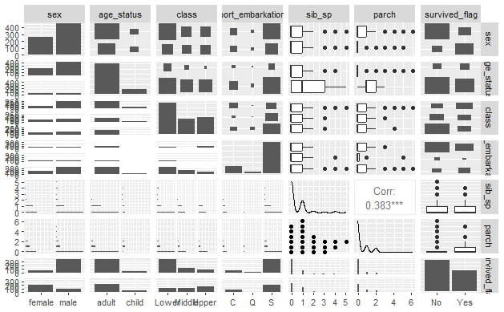

by sex females survived more than males, but there were more males than females in total.

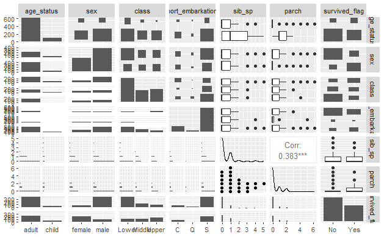

By age. Unfortunately, more adults than child survived

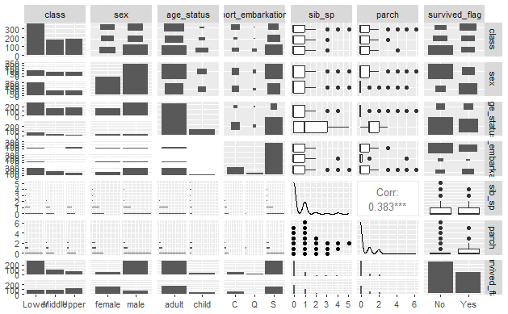

By Class, the upper class surviced more than the lower and middle clas, more death in lower class. Also its because there were more lower class than upper. It’s interesting that there were more upper than middle but there were more middle deathas than upper.

3. Train-test

```r
# create training set
titanic_train <- slice(titanic_clean, -test_index)
```

[output not shown]

#Check train/test

```r
titanic_test %>%
  janitor::tabyl(survived_flag)
```

[output not shown]

```r
titanic_train %>%
  janitor::tabyl(survived_flag)
```

```
 survived_flag   n   percent
            No 339 0.5947368
           Yes 231 0.4052632
```

4.Question. Decision Tree

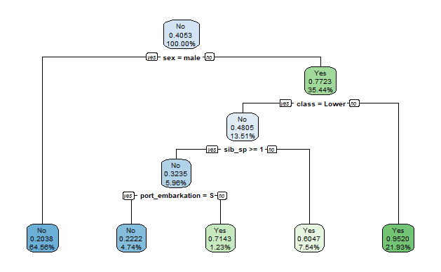

5. The plot shows that if you were a biological male your chance/ probability to survived were less than 35% without matter your social class.

Predictions

```r
library(modelr)
```

| sex | age_status | class | port_embarkation | sib_sp | parch | survived_flag | pred |
| --- | --- | --- | --- | --- | --- | --- | --- |
| male | adult | Middle | S | 0 | 0 | No | No |
| male | adult | Lower | S | 0 | 0 | No | No |
| male | adult | Lower | S | 1 | 0 | No | No |
| male | adult | Lower | S | 0 | 0 | No | No |
| female | child | Lower | S | 3 | 2 | No | No |
| female | adult | Upper | C | 1 | 0 | Yes | Yes |
| female | adult | Middle | S | 1 | 0 | Yes | Yes |
| male | adult | Lower | S | 1 | 1 | No | No |
| male | adult | Middle | S | 0 | 0 | No | No |
| male | adult | Lower | C | 0 | 0 | No | No |

[output cut: 132 more lines]

| survived_flag == pred | n |
| --- | --- |
| FALSE | 25 |
| TRUE | 117 |

According with the results , this predictive model has a positive result as probability - prediction of 82% (estimate). I feel that it is no the best model but it is good start.

| sex | class | port_embarkation | sib_sp | survived_flag |
| --- | --- | --- | --- | --- |
| male | Middle | S | 0 | No |
| male | Lower | S | 0 | No |
| male | Lower | S | 1 | No |
| male | Lower | S | 0 | No |
| female | Lower | S | 3 | No |
| female | Upper | C | 1 | Yes |
| female | Middle | S | 1 | Yes |
| male | Lower | S | 1 | No |
| male | Middle | S | 0 | No |
| male | Lower | C | 0 | No |

[output cut: 132 more lines]

Confusion matrix. Check my predictive performance

```r
conf_mat
```

```
          Truth
Prediction No Yes
       No  86  21
       Yes  4  31
```

# Calculate the accuracy

| .metric | .estimator | .estimate |
| --- | --- | --- |
| accuracy | binary | 0.8239437 |

The confusion matrix and the accuracy have confirmed the idea showed above about the positive result of the prediction.

# How sensitivity and specificity is the model?

| .metric | .estimator | .estimate |
| --- | --- | --- |
| sensitivity | binary | 0.9555556 |

| .metric | .estimator | .estimate |
| --- | --- | --- |
| specificity | binary | 0.5961538 |

#ConfusionMatrix

```r
library(caret)
```

```r
confusionMatrix(titanic_test_pred$pred,titanic_test_pred$survived_flag )
```

```
Confusion Matrix and Statistics

          Reference
Prediction No Yes
       No  86  21
       Yes  4  31

               Accuracy : 0.8239
                 95% CI : (0.7512, 0.8827)
    No Information Rate : 0.6338
    P-Value [Acc > NIR] : 5.685e-07

                  Kappa : 0.5926

 Mcnemar's Test P-Value : 0.001374

            Sensitivity : 0.9556
            Specificity : 0.5962
         Pos Pred Value : 0.8037
         Neg Pred Value : 0.8857
             Prevalence : 0.6338
         Detection Rate : 0.6056
   Detection Prevalence : 0.7535
      Balanced Accuracy : 0.7759

       'Positive' Class : No
```

As i said before, I feel that this is a good decision tree with a good prediction, accuracy and sensitive(true positives) but I feel a bit uncomfortable with the specificity that is not as high as other marks.